# ProvPack: pretty plots for provenance

Alex Lipp, agl18@ic.ac.uk / alex@lipp.org.uk

2019-06-27

# Installation

The package is stored on GitHub which allows it to be updated and maintained remotely. This also means that it is stored remotely and so is not in danger of being “lost” should anything happen. To install the package from the GitHub remotely you’ll need to install the `devtools` package. This can be done by running the following code:

```r
install.packages("devtools")
library("devtools")
install_github("CASPResearch/ProvPack")
```

At last check the package was working correctly with `R` version 3.6.0 at `ggplot2` version 3.2.0 which as of 27/6/19 is the most up to date versions.

# Introduction

Before using this package, I strongly recommend reading Pieter Vermeesch’s paper “An R package for statistical provenance analysis” which describes the basic functionality of the package “provenance” which these functions build on significantly (Vermeesch et al. 2016). It also has a good breakdown of the different approaches, which is beyond the scope of this vignette. You can get it Open Access here: http://www.ucl.ac.uk/~ucfbpve/papers/VermeeschSedGeol2016/. This paper should be cited if the functionality of a number of these functions are used!

This vignette describes some worked examples of using the package to analyse both distributional (e.g. age distributions) and compositional data. The code can all be run, and the data being analysed is in four .csv files (which should have come with the installation) called qemscandata.csv, rutiledata.csv, zircondata.csv and typing_palette.csv. If you don’t have these, they are available here: https://github.com/AlexLipp/ProvPack/tree/master/ProvPack/vignettes.

To get help with a specific function you can simply add a `?` before the function and run it, and this should display the documentation. e.g. `?load_distributional`

To use the package it needs to be loaded into the working environment with `library(ProvPack)`

This should print some lines to the console but you can ignore these. Now that this has been done, we can start using it to analyse data:

# Distributional Data

This walks through a simple example of making a series of plots from distributional data

The data-set being analysed is a series of Zircon U-Pb ages stored in a .csv file called “zircondata”. Within this spreadsheet the sample names are in the “SampleNo” column, ages in “PreferredAge” and the errors in “PreferredAge_2s”. Each sample has a classification listed in the “SandType” column.

##Typing

The package allows for the plots to be coloured according to some categorical variable. To do this, the samples need to have some categorical variable by which they can be classified. For example, geological formation they were sampled from, or the proposed proto-source region. In the examples used in this vignette, they samples are classified by their proposed provenance. e.g. Caledonian Sands, or Uralian sands. The colour scheme can either be automatically generated (by simply specifying the categorical variable) or a specific colour palette can be provided. To do this, we specify a “typing” palette, which is another .csv file. This contains in one column the “Categories” and the other “Co lours”. The categories correspond to the different classifications, e.g. Uralian, Caledonian etc… and the colour column is the different colours which are to be used, as given by a hexadecimal code (http://htmlcolorcodes.com/). An example is shown in typing_palette.csv. If we wanted to categorise the samples by something else (e.g. Formation) a different palette file would have to be generated. Note that the column headers should stay the same (i.e. “Category” and “Colour”). The different data-sets have to be re-loaded each time a new categorisation is desired.

## Loading distributional data

Distributional data is that which for each sample, it is the ‘distribution’ of data points which holds information about the sample. This includes any ‘spectrum’. The first step is to load the data into R’s memory. To do this we use the “load_distributional” function This takes as ‘arguments’ (inputs) the filename containing the data, the filename of the sandtypes, a tag which identifies the proxy (e.g. Zircon Ages), and a series of id’s which correspond to the column names in excel of Sample names, values (e.g. UPb ages) and the category we want to group the samples by, e.g. Sand Type.

Now, we load the zircon data into memory as a variable which we can call anything, e.g.’zircs’

```r
zircs <-
  load_distributional(
    "zircondata.csv",
    "Zircon Ages",
    "SampleNo",
    "PreferredAge",
    "SandType",
    "typing_palette.csv"
  )
```

This is a ‘distributional’ object, as defined in the provenance package which can be parsed by any of the normal ‘provenance’ functions. This uses the specified colour palette, but this does not have to be provided. If it is not, a rainbow colour map will be used. e.g.

```r
zircs <-
  load_distributional(
    "zircondata.csv",
    "Zircon Ages",
    "SampleNo",
    "PreferredAge",
    "SandType"
  )
```

By default the Kolmogorov-Smirnov dissimilarity matrix is used for all analyses, but the Sircombe-Hazleton dissimilarity is also implemented and can be calculated by specifying “SH = TRUE”. This requires the errors on each measurement to be specfied, and are loaded in by giving the tag of the column which they are stored in. In this case, the errors are in the column “PreferredAge_2s”.

```r
zircs <-
  load_distributional(
    "zircondata.csv",
    "Zircon Ages",
    "SampleNo",
    "PreferredAge",
    "SandType",
    "typing_palette.csv",
    "PreferredAge_2s",
    SH = TRUE
  )
```

However, we want to use the Kolmogorov-Smirnov statistic because it is a) grounded in statistics whereas the SH distance is not and b) is a lot faster. I generally recommend using the KS statistic, and so I wouldn’t really bother using the SH stuff above. To allow the KS statistic to be used we run:

```r
zircs$method <- "KS"
```

##Ridge plots##

Overlapping density plots (or ridgeplots) are good ways to display multiple distributions alongside eachother for comparison. They are implemented here as overlapping Kernel Density Estimates of the raw distributions of datas (see Vermeesch (2012)). KDEs are a very commonly used technique which smooths data according to a bandwidth which is analagous to a binwidth in a histogram. Having a fixed bandwidth is not appropriate for detritial data which is typically strongly multimodal. As as result KDEs are generated here by default using an ‘adaptive’ bandwidth which varies the bandwidth according the density of points (see Vermeesch (2016)). By default all the different KDEs are normalised to the same area for easy comparison.

They are made as follows:

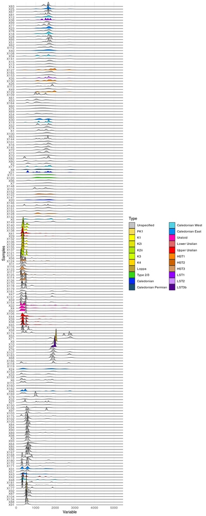

```r
ridgeplot <- makeridges(zircs)
print(ridgeplot)
```

This saves the ridgeplot into a variable called `ridgeplot` which is displayed using the `print` function.

```r
ridgeplot <-
  makeridges(
    zircs,
    samebandwidth = FALSE,
    normalise = FALSE,
    adaptive = FALSE
  )
```

Optionally, you can set the x-range over which the KDE’s are generated on which might be useful  
for data which is negative, e.g. Fsp-Pb ‘Model Ages’

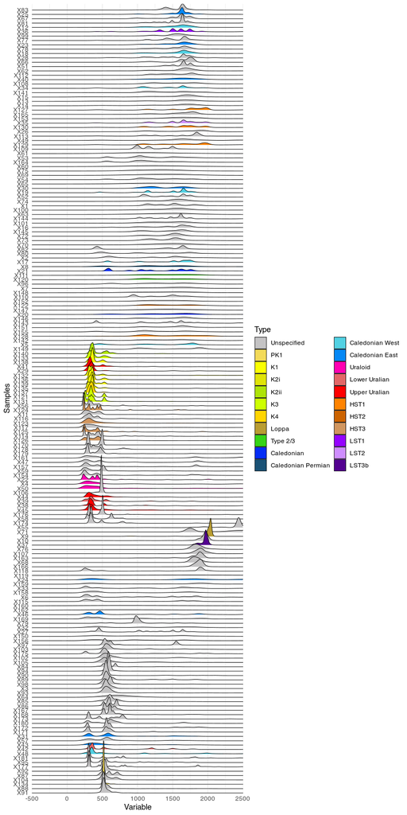

```r
ridgeplot <-
  makeridges(
    zircs, from = -500, to = 2500
  )
print(ridgeplot)
```

You’ll see that the generated ridgeplot is coloured by category and ordered into what (hopefully) look like similar groups. This is because they have automatically been sorted by a clustering analysis according to the KS distance between each sample. The details are not that important, but if you’d like instead for the samples to be ordered simply by category not this analysis you can indicate this by:

```r
ridgeplot <- makeridges(zircs, clustered = FALSE)
```

A key variable in making ridge plots is the degree of overlap between each distribution. The default is set to 10. This means that the highest point of all the distributions touches the bottom of the tenth distribution above him. I recommend just changing the different values of scale and seeing what looks best (e.g. limits covering up of important data, but maximises visibility) This can be done by:

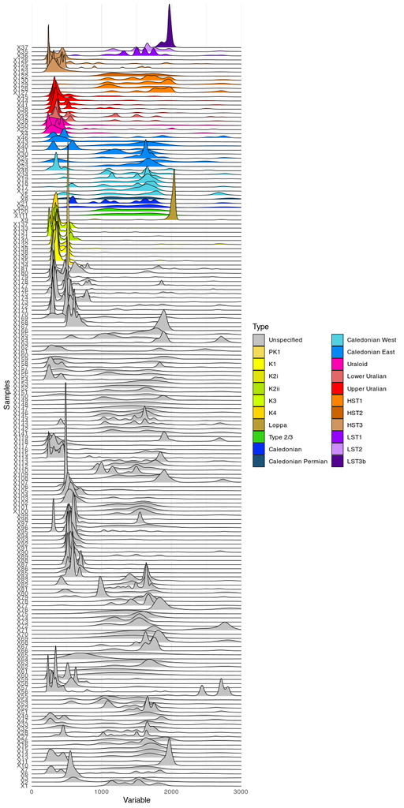

```r
ridgeplot <- makeridges(zircs, clustered = FALSE, from=0,to=3000,scale = 30)
print(ridgeplot)
```

The resulting plot can be modified to give it suitable, titles, labels etc… This is done by “adding on” to the ridgeplot variable. e.g. if I want to add a title I can do this by:

```r
ridgeplot <- ridgeplot + labs(title = "This is a title")
ridgeplot <- ridgeplot + labs(subtitle = "This is a subtitle")
ridgeplot <- ridgeplot + xlab("Age/Ma") + ylab("Sample Name") + labs(fill = "Sand Type")
# These functions relabel the x and y axes and the last one changes the title of the legend.
# The size of samplename labels is a bit big, so this can be changed with:
ridgeplot <- ridgeplot + theme(axis.text.y = element_text(size = rel(0.7)))
# We also might want to set the x limits between 0 and 3000, we can do this with:
ridgeplot <- ridgeplot + scale_x_continuous(expand=c(0,0),limits=c(0,3000))
#Ignore the 'expand' bit, the values after limits are the limits we want. Also ignore the warning.
```

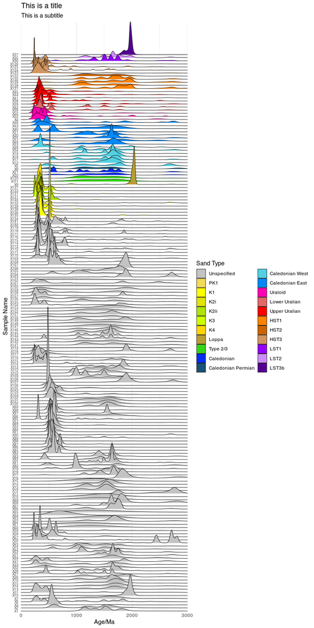

```r
print(ridgeplot,echo=FALSE)
```

If you are feeling adventurous, you can pretty much change everything about the plot which is simply a “ggplot2” object. If you search online for ggplot2 documentation there is a wealth of literature so you can pretty much do anything to do with it. Alternatively you can just save it as a .pdf (see below) and edit it in InkScape or CorelDraw etc…

Now that we have a nice looking plot, we can save it with the ggsave function. You need to give it a filename (can be anything but the file type is important!), and the plot to save as well as optionally some widths and heights, with unit’s specified.

```r
ggsave(
  "zirconridgeplot.pdf",
  ridgeplot,
  width = 210,
  height = 297,
  units = "mm"
)
```

The above saves the plot as ‘zirconridgeplot’, a .pdf file which is A4 in size (210 x 297 mm’s). This will be saved in the “working directory” specified at the start

If you save it as a bitmap file like .JPEG or .PNG, it’s worth specifying a high DPI because the default is very low. e.g:

```r
ggsave(
  "zirconridgeplot.jpeg",
  ridgeplot,
  width = 210,
  height = 297,
  units = "mm",
  dpi = 600
)
```

##Multidimensional Scaling (MDS) Map

MDS plots are useful ways to summarise large data-sets graphically and illustrate different groups. The aim of MDS is to take a matrix of dissimilarity measures (e.g. Kolmogorov-Smirnov distances) and transform that into a set of 2D coordinates such that the 2D distance between the points approximates the initial dissimilarity. This can be done by executing the following code:

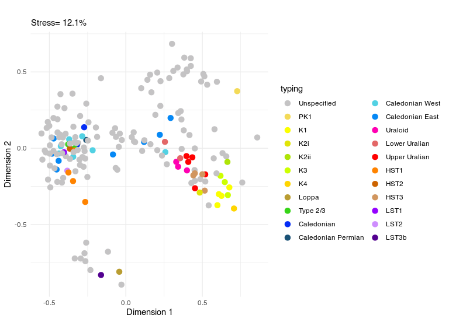

```r
MDSplot <- makeMDSmap(zircs)
```

The sub-title for each plot is automatically set to be the ‘Stress’ of the MDS analysis for non-metric MDS and the percentage of variation contained for classical (see below). These values are also printed to the console at different stages of the iteration and just indicate the algorithm progressively minimising this. The ‘Stress’ is effectively a ‘goodness’ of fit parameter, describing how well the data can be represented on a 2D plane. Kruskal (1964) define the following categorisations of ‘Stress’ but, at the end of the day the analysis is only as useful as the testable conclusions it is possible to draw from them. So don’t take them at face value:

| Stress | Goodness of fit |
| --- | --- |
| 20% | poor |
| 10% | fair |
| 5% | good |
| 2½% | excellent |
| 0% | “perfect” |

The percentage variation described in classical MDS corresponds to the amount of total variation within the entire data-set which can be described in terms of the two principal components. The rest of the variation is ‘out-of-plane’. Again, don’t take at face value, but it’s good to have displayed.

It’s also possible to use the “classical” form of MDS which preserves distances, but can be less effective This is however, only possible for “Euclidean” dissimilarity measures like the KS distance (and NOT the SH dissimilarity). The following generates a classical MDS plot

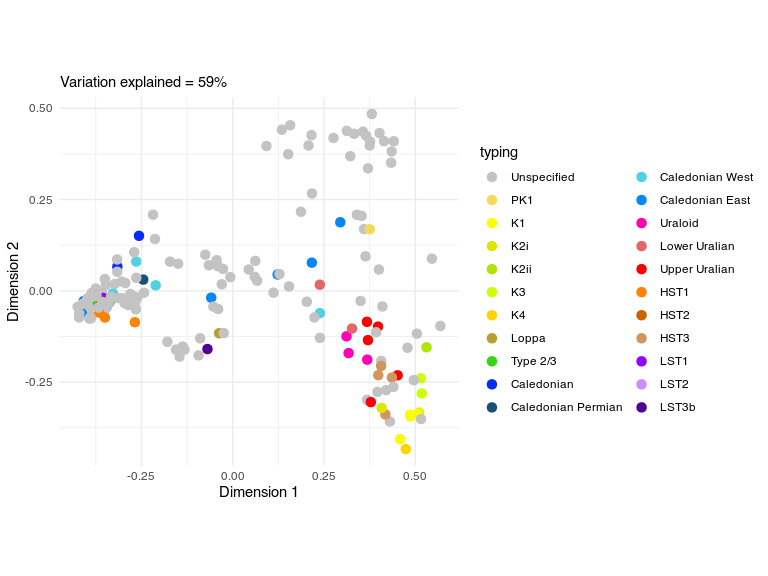

```r
MDSplot <- makeMDSmap(zircs, classical = TRUE)
```

If you have initialised the distributional object with the Sircombe-Hazleton dissimilarity, this can be used too (Sircombe & Hazleton, 2004). However, I have found this generally to be not very useful, and recommend just using the KS statistic. If you want to do this, you just set the `method` to “SH” and run the analysis as normal. Be warned however, this can throw up some errors, and can take a LONG time.

```r
zircs$method <- "SH"
```

Like the ridge plots, the MDS maps are “ggplot” objects and thus can be modified and saved accordingly. You can add labels to the plot by changing the `labels` argument to `TRUE` For large-datasets R can be a bit funny if the plot viewer in the lower right is small, so if you get errors just try enlarging it.

##Lower Quartile vs Upper Quartile plots

Upper vs Lower quartile plots are useful ways of distinguishing different groups of similar distributions but unlike MDS retains geological information in the form the Lower quartile age and the Upper quartile age (Anderson et al. 2017). These can be very simply produced with:

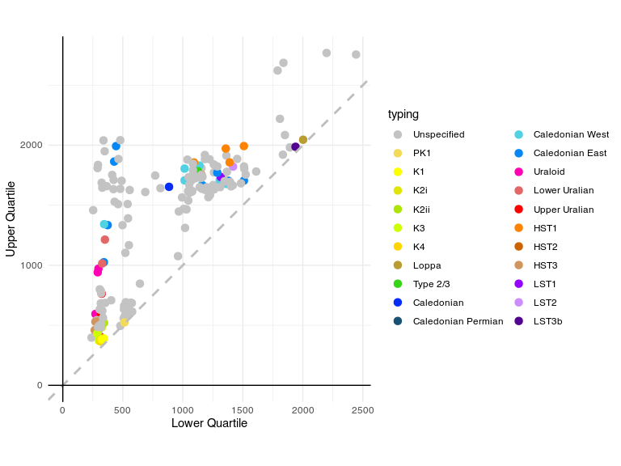

```r
makeQQplot(zircs)
```

These can be adjusted as normal plots like above. The function above automatically adds a 1:1 line to the QQplot, but it can also be useful to have parallel 1:1 sloped lines to guide the eye, to distributions which are more spread out (i.e. further from y=x line) The following line adds 1:1 lines with y-intercepts at 500, 1000, 1500 and 2000. The style can be adjusted by changing the other parameters.

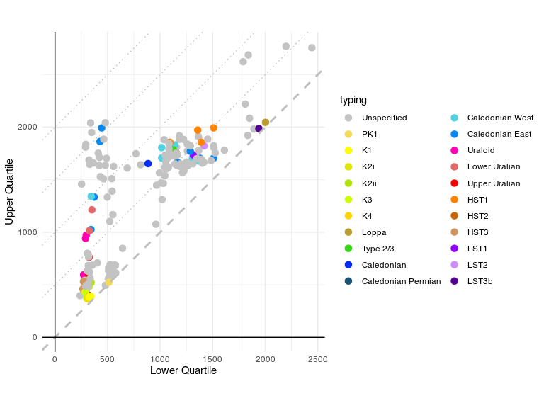

```r
QQplot <-
  makeQQplot(zircs) + geom_abline(
    intercept = c(500, 1000, 1500, 2000),
    slope = 1,
    colour = "grey",
    size = 0.5,
    linetype = "dotted"
  )
print(QQplot)
```

# Compositional Data

In contrast to distributional data, compositional data is anything which describes the constituent nature of a sample. This includes petrography, heavy minerals and major elements. The hall-marks of compositional data-sets is that for each sample the data adds up to a constant (e.g. 100%) and that the information lies not in the actual raw value for each variable, (e.g. 15 point counts of a mineral is independently meaningless) but the relative value. A compositional data-set is loaded by:

```r
qems <- load_compositional(
  datafilename = "qemscandata.csv",
  tag = "Qemscan",
  sample_id = "SampleNo",
  val_range = c(3, 42),
  type_id = "SandType",
  typing = "typing_palette.csv"
)
```

This is a ‘compositional’ object which can be parsed by any of the normal ‘provenance’ functions

The statistical analysis of compositional data is a vibrant subfield of mathematical geology (http://www.compositionaldata.com/) with much analysis requiring the transformation of the data-set into log-space (Aitchison, 1986) A problem resulting from this is that ‘zero’ values require special treatment (Martin-Fernandez et al. 2003) Broadly speaking there are ‘essential zeros’ and ‘rounded zeros’. Rounded zeros represent measurements which are not truly ‘null’ but simply below a delection limit (BDL). Essential zeros however truly do represent a complete absence of that particular component. In provenance, most zero values in a data-set are rounded zeros and can be suitably dealt with for subseqent analysis. This replacement of rounded zeros is called ‘imputation’ of which there are a range of techniques. The standard measure for comparing compositional data is the “Aitchison Distance” (Aitchison, 1982) however this requires no zero values. Thus, if the data-set contains zeros, the default method is the “Bray-Curtis” dissimilarity (Bray & Curtis, 1957). However, this measure is non-euclidean so cannot be used in Principal Components Analysis thus it is very advisable to try removing/replacing zero values so that the aitchison distance can be used. This also allows the data-set to be transformed into a log-space which allows for a wealth of further analysis (see the “compositions” package)

To investigate how many zero values there are within a data-set there is the function:

```r
fractionzeros(qems)
```

```
## [1] 0.3498804
```

This tells us that about 35% of values in the data-set above are zero’s. This is quite a lot, and more than is considered appropriate to try imputing replacement values (10%) A good first step to solve zero’s is amalgamation where different components are grouped together (e.g. Plagioclase = Albite + Anorthite + oligoclase etc…) Vermeesch (2016)’s package implements this feature, demonstrated below:

```r
#This loads the functions in "provenance"
library(provenance)
```

```r
qem_amalg <-
  amalgamate(
    qems,
    Quartz = "Quartz",
    Kfsp = "KFeldspar",
    Plag = c("Albite", "Oligoclase", "AndesineAnorthite"),
    Porosity = "Porosity",
    Micas = c("Biotite", "Muscovite"),
    Clays = c(
      "Illite",
      "Chlorite",
      "Kaolinite",
      "Glauconite",
      "Smectite",
      "QuartzClayMix",
      "OtherClays"
    ),
    HeavyMins = c(
      "Zircon",
      "Tourmaline",
      "Garnet",
      "Epidote",
      "Titanite",
      "Kyanite",
      "Staurolite",
      "Amphibole_CPX",
      "OPX",
      "Rutile_Anatase",
      "CrSpinel",
      "Apatite",
      "Monazite"
    ),
    Diagenetic
    = c(
      "Calcite",
      "Dolomite",
      "FeDolomite",
      "Ankerite",
      "Siderite",
      "FeOxides",
      "Pyrite",
      "Barite",
      "Anhydrite",
      "Halite"
    )
  )
fractionzeros(qem_amalg)
```

```
## [1] 0.01674641
```

However, this still contains zero’s (2%) so these still need to be dealt with. For small amounts of zeros <10% we can ‘impute’ a suitably small value which acts in the same way. This function implements the multiplicative replacement strategy of Martin-Fernandez et al. (2003). The replacement value is the detection limit of the data-set, multiplied by a scalar (default at 0.65)

```r
qem_rep <- replacezeros(qem_amalg,detlim = 0.0025)
```

If a ‘detection limit’ is not provided, instead the smallest non-zero value in the entire data-set is taken as an approximation of the detection limit, e.g.

```r
qem_rep <- replacezeros(qem_amalg)
```

It is recommended that senstivity analysis is performed by adjusting the scalar value from 0.2 to 2 (Aitchison 1986).

Now that zero’s have been replaced, the data-set can be subject to any analysis, and the Aitchision distance can be used. This can be set as the default method by:

```r
qem_rep$method <- "aitchison"
```

If this isn’t done, the Bray-Curtis will be used, but it is not as powerful. ## Ternary Plots

A simple way to visualise compositional data is on ternary phase diagrams. These can be used using this package with the “maketernaryplot” function.

This plots three components against eachother, and colours the points according to the categorical variables. For example:

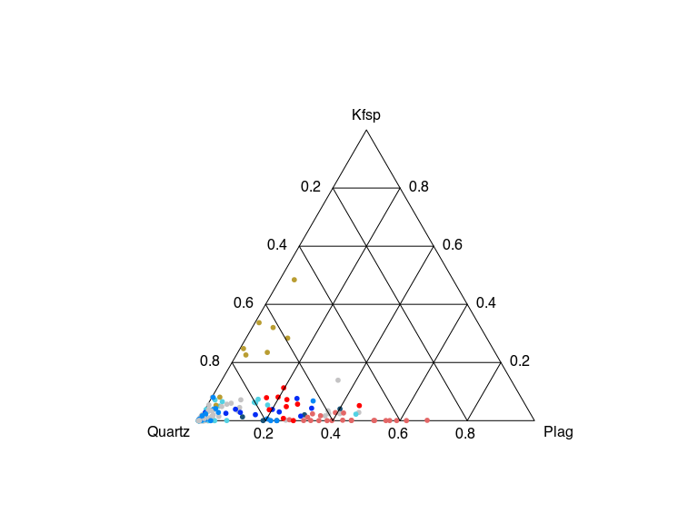

```r
maketernaryplot(qem_rep,"Quartz","Plag","Kfsp")
```

This plot can be modified in a number of helpful ways. Isoportion lines can be turned off by:

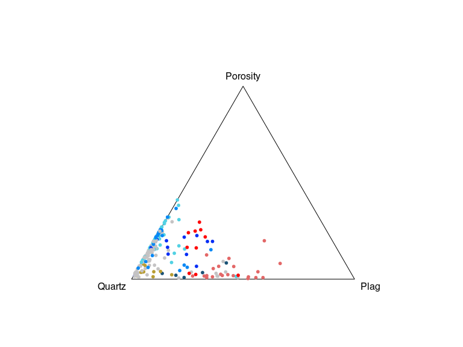

```r
maketernaryplot(qem_rep,"Quartz","Plag","Porosity",isoportions = FALSE)
```

The size of the points can be changed by the “size” parameter:

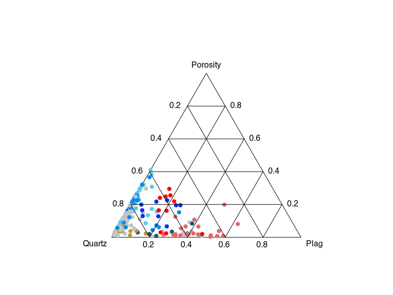

```r
maketernaryplot(qem_rep,"Quartz","Plag","Porosity",isoportions = TRUE,size=1.5)
```

### Centering A very useful but rarely used technique to help visualise ternary phase diagrams better is “centering”. This technique alters the ternary phase diagram by shifting the mean of the dataset into the centre of the phase diagram (Eynatten et al. 2002). This is very useful in cases when the composition is dominated by one or two components and thus points cluster towards the edges. For example, the above cases show this clustering in one corner. We can “center” the data like so:

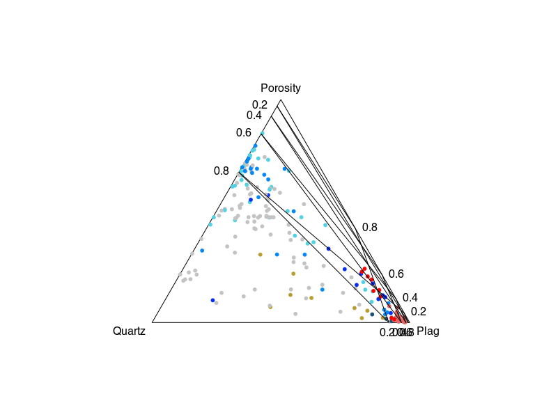

```r
maketernaryplot(qem_rep,"Quartz","Plag","Porosity",centered = TRUE)
```

The geometric centre of the data now lies at the centroid of the triangle. This now has expanded the data-set and allows the variation within the Caledonian blue samples to be seen more easily. See Eynatten et al 2002.

The objects created by the ternary phase plotter is *not* a ggplot object like the other plots. As a result it is saved in a slightly different way. As follows:

```r
png("ternaryplot.png",width=100,height=100,units="mm",res=300)
maketernaryplot(qem_rep,"Quartz","Plag","Kfsp")
dev.off()
```

This first opens a “png” and then saves the plot to it. Note that when this is run, this needs to be followed by the expression `dev.off()` which closes the connection. Saving it as a .pdf is analagous.

## Principal Component Analysis

Non-metric MDS can be performed much like distributional data:

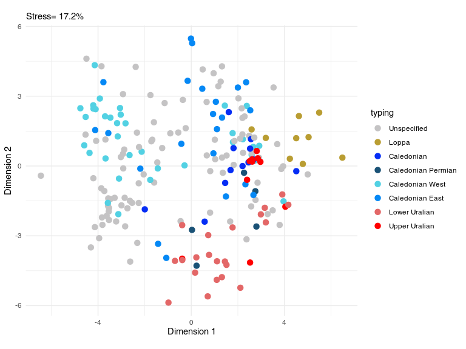

```r
MDSplot <- makeMDSmap(qem_rep)
```

However, a better analagous approach is principal component’s analysis (see Vermeesch 2016) To produce a PCA bi-plot of a data-set use the makePCAbiplot function:

```
## [1] "Cumulate proportional variation:"
##    Comp.1    Comp.2    Comp.3    Comp.4    Comp.5    Comp.6    Comp.7
## 0.3988105 0.6480543 0.8345766 0.9312910 0.9647434 0.9848457 1.0000000
##    Comp.8
## 1.0000000
```

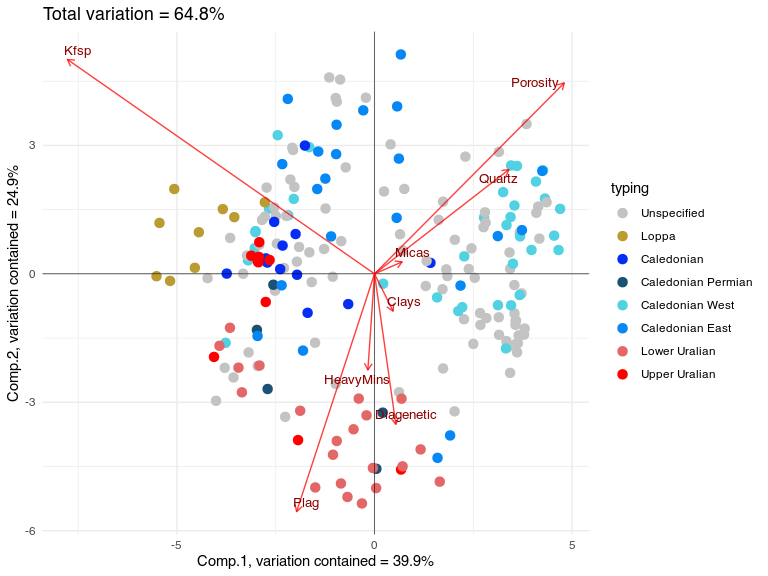

```r
makePCAbiplot(qem_rep,haxis="Comp.1",vaxis="Comp.2")
```

For advice on interpreting a biplot referred to the free book on the topic at: (http://www.multivariatestatistics.org/biplots.html).

PCA works by determining a series of orthogonal “components” which explain the variation of the data-set. The first component has the largest amount of variation loaded onto it, with subsequent components containing less and less, and the last having no variation at all. This dimensionality reduction allowswhat is initially a system of many variables to be explained in a smaller number of variables. The proportional variance on each component is printed to the console when the analysis is performed the components which are being mapped onto the horizontal and vertical axis can be changed by:

```
## [1] "Cumulate proportional variation:"
##    Comp.1    Comp.2    Comp.3    Comp.4    Comp.5    Comp.6    Comp.7
## 0.3988105 0.6480543 0.8345766 0.9312910 0.9647434 0.9848457 1.0000000
##    Comp.8
## 1.0000000
```

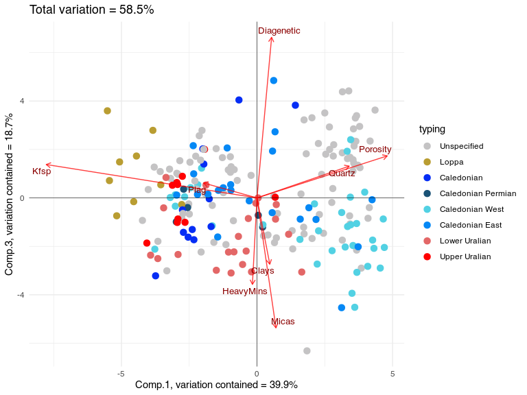

```r
makePCAbiplot(qem_rep,haxis="Comp.1",vaxis = "Comp.3")
```

Where you can simply change the number after Comp. between 1 and the number of different variables

## CLR Scatterplots

There are a number of problems with plotting raw compositional data variables against one another in scatter plots. Most notably is the ‘spurious’ correlation between two ratios (Pearson 1897) A way to avoid this is to transform the data-set into log-space (see above). The “compositions” R package is very comprehensive and the reader is referred there. This package however does implement a function which allows two variables to be plotted against eachother on a scatter-plot but after being tranformed by the Centred Log-Ratio (CLR). For example:

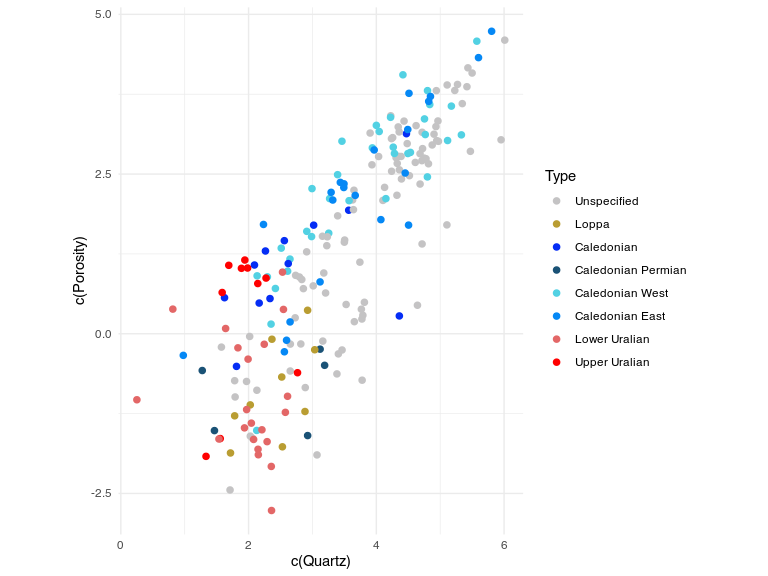

```r
scatter <- clrscatterplot(qem_rep,"Quartz","Porosity")
print(scatter)
```

This reveals the strong relationship between the relative amounts of porosity and quartz within a sandstone. However, CLR transformations are still not perfect for a rigorous linear regression analysis as the covariance matrix of CLR transformed data is singular. The best approach is to transform the data into ILR variables, which is implemented in the “compositions” package. See (Filzmoser & Hron, 2008)

# Multi-proxy comparison

It’s possible to go up another level of statistical abstraction to try and analyse how each different data-set is subtly different. There are two ways of doing this implemented here and in Vermeesch’s original package. INdividual Differences SCALing (INDSCAL) and Procrustes Analysis. ##INDSCAL INDSCAL is effectively the same analysis as MDS but generalised to 3D dissimilarity matrices (in contrast to 2D ones used prior). INDSCAL produces both a ‘map’ analagous to MDS map’s but also vector’s corresponding to the ‘source weights’ of each different dissimilarity matrix. What this means is that it’s possible to describe the group configuration in terms of the individual proxies. Showing by example, lets load up 3 data-sets…

```r
zircs <- load_distributional("zircondata.csv","Zircon Ages","SampleNo","PreferredAge","SandType","typing_palette.csv","PreferredAge_2s",SH=F)
rus <- load_distributional("rutiledata.csv","Rutile Ages","SampleNo","Pb207_Corr","SandType","typing_palette.csv")
rutmps <- load_distributional("rutiledata.csv","Rutile Temps","SampleNo","TempWatson","SandType","typing_palette.csv")
```

… and peform INDSCAL on them:

```r
inds <- makeindscalmap(zircs,rus,rutmps,typing="typing_palette.csv")
```

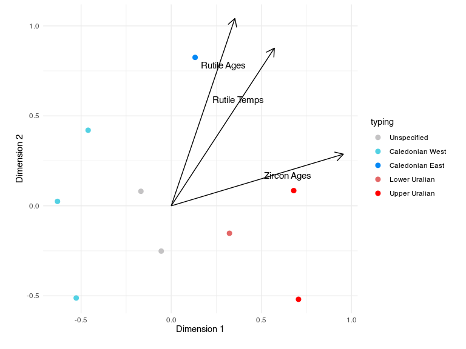

```r
print(inds)
```

Each dissimilarity matrix was generated with the default method for each dataset. This can be seen with zircs$method

Firstly you see that the only samples which are plotted are those which belong in *all* of the chosen data-sets. Secondly you will see points coloured by category and lines labelled by different analyses. These are the ‘group configuration’ and ‘source weights’ respectively. You should see that the rutile analysis source weights are broadly parallel. This indicates that the two different proxies discriminate samples in a similar way. e.g. if sample X is different to Y by rutile age, it is likely to be similarly different by rutile temperature. In contrast, the zircon age vector is different.

We can use these source-weights to interpret the configuration by treating them simply as normal axes. For example, the Caledonian East samples are further along the rutile axes than the Caledonian West samples, indicating that they have different rutile ages/temps. However, both these groups lie broadly along a line perpendicular to the zircon vector suggesting they all have similar zircon age spectrum. Finally, the Uralian samples have similar rutile age/temp spectrum to the Cal. West samples but, a distinct zircon spectra. This is confirmed by inspecting the individual spectra. Thus this analysis gives us good evidence that we can use rutile to distinguish the East and West caledonian sand-types, but not with Zircon age spectra.

The colour palette file is optional, and if it is not provided a rainbow palette is generated instead.

```r
inds <- makeindscalmap(zircs,rus,rutmps)
```

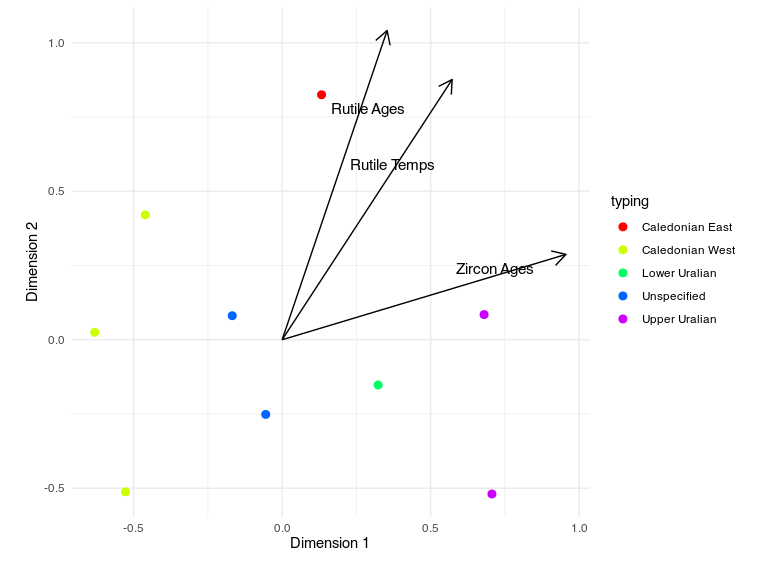

```r
print(inds)
```

##Procrustes Analysis

Procrustes analysis is similar to INDSCAL but works in a different way. It takes each individual MDS map, and then rotates, reflects and scales them to produce a ‘consensus’ view which minimises a least-squares criterion. It can be performed via:

```r
proc <- makeprocrustesmap(zircs,rus,rutmps,typing="typing_palette.csv")
```

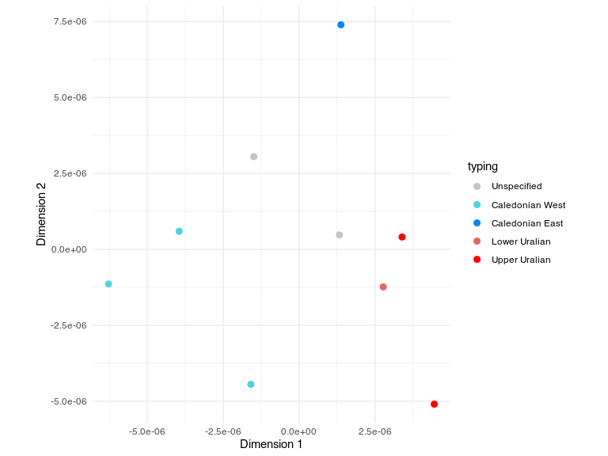

It should show similar results to the INDSCAL analysis, but lacks the source weights. It’s possible to change the dissimilarity measure used by these analyses, by specifying it as follows. By default for distributional data it is set to KS, and for compositional aitchison distance. For example we now specify that in the multi-proxy comparisons we want zircon’s to be compared using the Sircombe-Hazleton distance:

```r
zircs$method <- "SH"
proc <- makeprocrustesmap(zircs,rus,rutmps,typing="typing_palette.csv")
```

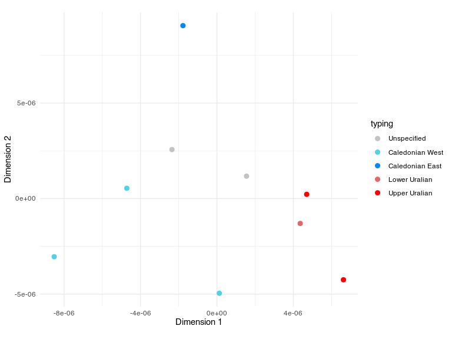

The result will be different because the input dissimilarity matrix is different, however the conclusions drawn are unlikely to be wildly distinct. Generally I reccommend using the KS distance for distributional data and Aitchison distance for compositional data.

#Conclusion

This should be all up and running now, and you can run all the functions. If there are any problems using R, google is your friend and there is a large body of helpful information in getting started with R on the internet, particularly on https://stackoverflow.com/. However, if you have any further problems or want to add something to the package, feel free to contact me.

#References

**Aitchison, J., 1986.** *The statistical analysis of compositional data.* Chapman and Hall.

**Aitchison, J., 1982.** *The Statistical Analysis of Compositional Data.* J. R. Stat. Soc. Ser. B Methodol. 44, 139–177.

**Andersen, T., Kristoffersen, M., Elburg, M.A., 2017.** *Visualizing, interpreting and comparing detrital zircon age and Hf isotope data in basin analysis – a graphical approach.* Basin Res. https://doi.org/10.1111/bre.12245

**Bray, J.R., Curtis, J.T., 1957.** *An Ordination of the Upland Forest Communities of Southern Wisconsin.* Ecol. Monogr. 27, 325–349. https://doi.org/10.2307/1942268

**Buccianti, A., 2013.** *Is compositional data analysis a way to see beyond the illusion?* Comput. Geosci., Benchmark problems, datasets and methodologies for the computational geosciences 50, 165–173. https://doi.org/10.1016/j.cageo.2012.06.012

**Daunis-I-Estadella, J., Barceló-Vidal, C., Buccianti, A., 2006.** *Exploratory compositional data analysis.* in Geol. Soc. Lond. Spec. Publ. 264, 161–174. https://doi.org/10.1144/GSL.SP.2006.264.01.12

**Eynatten, H. von, Pawlowsky-Glahn, V., Egozcue, J.J., 2002.** *Understanding Perturbation on the Simplex: A Simple Method to Better Visualize and Interpret Compositional Data in Ternary Diagrams.* Math. Geol. 34, 249–257. https://doi.org/10.1023/A:1014826205533

**Filzmoser, P., Hron, K., 2009.** *Correlation Analysis for Compositional Data.* Math. Geosci. 41, 905. https://doi.org/10.1007/s11004-008-9196-y

**Kruskal, J.B., 1964.** *Multidimensional scaling by optimizing goodness of fit to a nonmetric hypothesis.* Psychometrika 29, 1–27. https://doi.org/10.1007/BF02289565

**Martín-Fernández, J.A., Barceló-Vidal, C., Pawlowsky-Glahn, V., 2003.** Dealing with Zeros and Missing Values in Compositional Data Sets Using Nonparametric Imputation. Math. Geol. 35, 253–278. https://doi.org/10.1023/A:1023866030544

**Sircombe, K.N., Hazelton, M.L., 2004.** *Comparison of detrital zircon age distributions by kernel functional estimation.* Sediment. Geol., Quantitative Provenance Analysis of Sediments 171, 91–111. https://doi.org/10.1016/j.sedgeo.2004.05.012

**Vermeesch, P., 2013.** *Multi-sample comparison of detrital age distributions.* Chem. Geol. 341, 140–146. https://doi.org/10.1016/j.chemgeo.2013.01.010

**Vermeesch, P., Garzanti, E., 2015.** *Making geological sense of ‘Big Data’ in sedimentary provenance analysis.* Chem. Geol. 409, 20–27. https://doi.org/10.1016/j.chemgeo.2015.05.004